# TreeClassification-HighRes-IndividualUser

Aitor Apaolaza

12/01/2016

*Copyright (c) 2015 The University of Manchester, UK.*

*Licenced under LGPL version 2.1. See LICENCE for details.*

*The IDInteraction Attention Classification was developed in the IDInteraction project, funded by the Engineering and Physical Sciences Research Council, UK through grant agreement number EP/M017133/1.*

*Author: Aitor Apaolaza*

## Initialisation and loading data

```
## [1] "All listed packages are already installed"
```

# Setup for the classification algorithm.

**Folder**: /home/aitor/Dropbox/UoM/IDInteractionCode/Rnotebooks

**Experiment**: dual_screen_free_experiment

**Source Videos**: high_quality

**Tracking system**: front_full_face

**Using the following list of participants**: P06.

**Using the following timelimit threshold to separate training and testing data**: 1.

Data for these participants will be read from the CSV files contained in the following folders:

/home/aitor/Dropbox/UoM/IDInteractionCode/Rnotebooks/resources/dual_screen_free_experiment/high_quality/attention/

/home/aitor/Dropbox/UoM/IDInteractionCode/Rnotebooks/resources/dual_screen_free_experiment/high_quality/front_full_face/

Loading data for participant P06

```
## [1] "Processing participant: P06"
## [1] "START of combineCSVsToDF()"
## [1] "END of combineCSVsToDF()"
## [1] "START of createFeatureDF()"
## [1] "END of createFeatureDF()"
```

## Training the tree classifier

Using the **rpart** library for the following formula:

**attentionName ~ boxHeight + boxRotation + boxArea + boxWidth + widthHeightRatio + boxYcoordRel**

Resulting model:

```
## n= 2798
##
## node), split, n, loss, yval, (yprob)
##       * denotes terminal node
##
##  1) root 2798 1244 tv (0.44460329 0.55539671)
##    2) boxYcoordRel>=0.6931121 1215   87 ipad (0.92839506 0.07160494)
##      4) boxRotation>=8.320245 1139   52 ipad (0.95434592 0.04565408) *
##      5) boxRotation< 8.320245 76   35 ipad (0.53947368 0.46052632)
##       10) boxYcoordRel>=0.8210995 41    0 ipad (1.00000000 0.00000000) *
##       11) boxYcoordRel< 0.8210995 35    0 tv (0.00000000 1.00000000) *
##    3) boxYcoordRel< 0.6931121 1583  116 tv (0.07327858 0.92672142)
##      6) boxRotation>=15.1639 438   93 tv (0.21232877 0.78767123)
##       12) boxYcoordRel>=0.643797 151   62 ipad (0.58940397 0.41059603)
##         24) boxHeight< 43.60775 105   21 ipad (0.80000000 0.20000000) *
##         25) boxHeight>=43.60775 46    5 tv (0.10869565 0.89130435) *
##       13) boxYcoordRel< 0.643797 287    4 tv (0.01393728 0.98606272) *
##      7) boxRotation< 15.1639 1145   23 tv (0.02008734 0.97991266) *
```

From the R manual for the Complexity Parameter Table for an Rpart Fit: *The cptable in the fit contains the mean and standard deviation of the errors in the cross-validated prediction against each of the geometric means.*

Matrix of information on the optimal prunings based on a complexity parameter.

```
##
## Classification tree:
## rpart(formula = formula, data = trainsetclass, method = "class")
##
## Variables actually used in tree construction:
## [1] boxHeight    boxRotation  boxYcoordRel
##
## Root node error: 1244/2798 = 0.4446
##
## n= 2798
##
##         CP nsplit rel error   xerror      xstd
## 1 0.836817      0  1.000000 1.000000 0.0211296
## 2 0.016881      1  0.163183 0.168006 0.0111788
## 3 0.014068      4  0.112540 0.127814 0.0098441
## 4 0.010000      6  0.084405 0.098875 0.0087171
```

Visualisation of the Complexity Parameter Table. *A good choice of cp for pruning is often the leftmost value for which the mean lies below the horizontal line.*

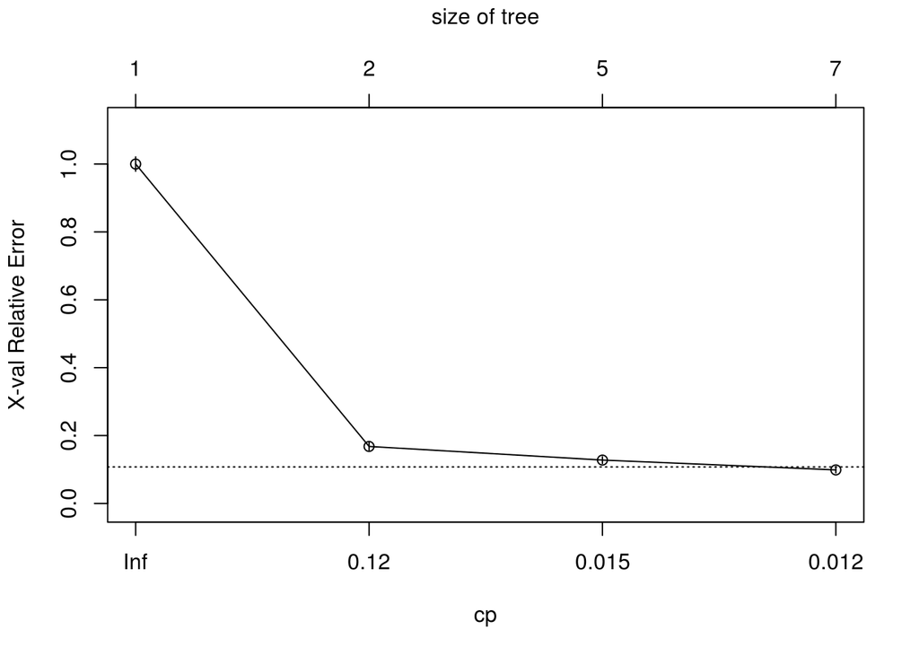

## Tree

### Summary of the tree

```
##
## Model formula:
## attentionName ~ boxHeight + boxRotation + boxArea + boxWidth +
##     widthHeightRatio + boxYcoordRel
##
## Fitted party:
## [1] root
## |   [2] boxYcoordRel >= 0.69311
## |   |   [3] boxRotation >= 8.32024: ipad (n = 1139, err = 4.6%)
## |   |   [4] boxRotation < 8.32024
## |   |   |   [5] boxYcoordRel >= 0.8211: ipad (n = 41, err = 0.0%)
## |   |   |   [6] boxYcoordRel < 0.8211: tv (n = 35, err = 0.0%)
## |   [7] boxYcoordRel < 0.69311
## |   |   [8] boxRotation >= 15.1639
## |   |   |   [9] boxYcoordRel >= 0.6438
## |   |   |   |   [10] boxHeight < 43.60775: ipad (n = 105, err = 20.0%)
## |   |   |   |   [11] boxHeight >= 43.60775: tv (n = 46, err = 10.9%)
## |   |   |   [12] boxYcoordRel < 0.6438: tv (n = 287, err = 1.4%)
## |   |   [13] boxRotation < 15.1639: tv (n = 1145, err = 2.0%)
##
## Number of inner nodes:    6
## Number of terminal nodes: 7
```

### Visualisation of the tree

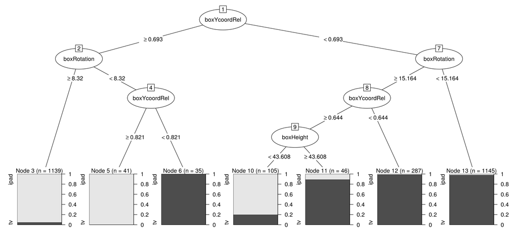

Tree classifier plot

## Error metrics analysis

Confusion matrix from the application of the tree predictor to the testing set of data.

```
##       predclass
##         ipad    tv
##   ipad 10472  2688
##   tv   13506 16503
```

### Error metrics based on prediction of attention to the iPad.

True negatives: 16503

True positives: 10472

**Error-rate**: the proportion of the incorrectly classified examples -> (fp+fn)/(tp+tn+fp+tn)

**37.5130302**

**Accuracy**: the proportion of the correctly classified examples -> (tp+tn)/(tp+tn+fp+tn)

**62.4869698**

As the number of instances of the response variable is not balanced (there are many more instances with false than true) the accuracy is not a good indicator. Other cost sensitive measures are reported here. -> cost sensitive measures

**F measure**: the balance between precision and recall -> 2*tp/(2*tp+fp+fn)

**56.395067**

### Error metrics based on prediction of attention to the TV.

True negatives: 10472

True positives: 16503

**Error-rate**: the proportion of the incorrectly classified examples -> (fp+fn)/(tp+tn+fp+tn)

**37.5130302**

**Accuracy**: the proportion of the correctly classified examples -> (tp+tn)/(tp+tn+fp+tn)

**62.4869698**

**F measure**: the balance between precision and recall -> 2*tp/(2*tp+fp+fn)

**67.0853659**